# Leefomstandigheden inwoners met een Antilliaanse achtergrond in Den Haag

21-10-2018

## Eerder onderzoek

Zorgelijk beeld van de leefomstandigheden van kinderen met een Antilliaanse- of Arubaanse achtergrond in Nederland (Tierolf, Steketee, Gilsing & Bellaart, 2017)

## Wat viel op t.o.v.kinderen andere herkomst?

- Scoren hoogst op de risico’s armoede, eenoudergezinnen, jeugdwerkloosheid en gebruik jeugdhulp.
- Ze wonen vaker in slechtere en kansarme wijk
- Ze voelen zich daar minder veilig
- Een deel van hen doet het relatief goed in onderwijs en op arbeidsmarkt

## Vraag

> Actieve organisaties voor en door Antilliaanse Nederlanders in Den Haag (HAAB en OCAN) verzochten Kennisplatform Integratie & Samenleving om deze situatie in kaart te brengen

## Presentatie van:

1. Antilliaanse-Nederlanders in Den Haag
2. Opleidingsniveau en Onderwijs

## 1. Antilliaanse-Nederlanders in Den Haag

## Inwoners van Nederland

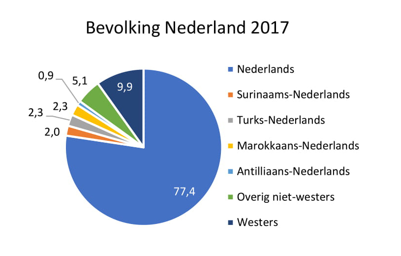

Bron: CBS Statline 2018

## Inwoners Den Haag

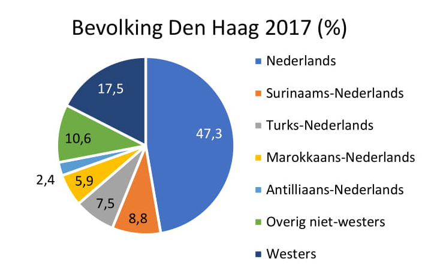

Bron: CBS Statline 2018

## Vergelijking G4-steden

[output not shown]

## Verdeling naar wijken in Den Haag

| Bepaalde wijken | Percentage |
| --- | --- |
| Stationsbuurt | 8,4% |
| Laakkwartier | 4,8% |
| Moerwijk | 4,8% |

## Leeftijdsopbouw

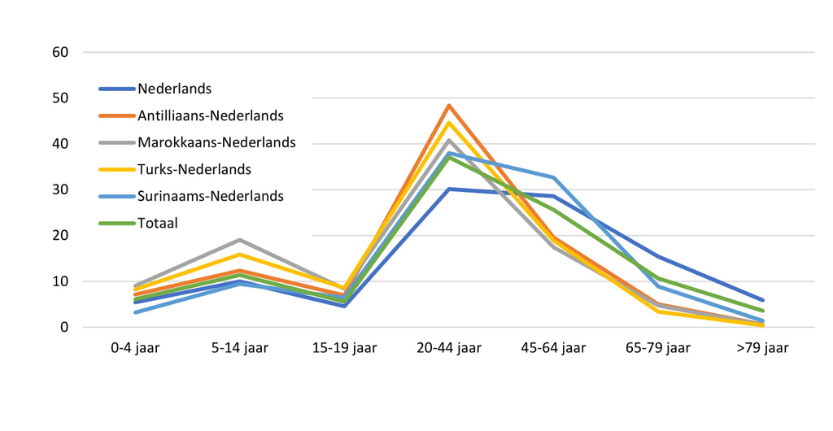

Bron: Buurtmonitor Den Haag 2017

## Percentages eenoudergezinnen naar herkomst

| Herkomst | Den Haag | Rotterdam |
| --- | --- | --- |
| Nederlands | 6,9% | 6,1% |
| Surinaams-Ned | 18,1% | 22,3% |
| Antilliaans-Ned | 17,2% | 23,9% |
| Turks-Ned | 13,1% | 13,7% |
| Marokkaans-Ned | 12,2% | 15,2% |
| Westers | 7,3% | 8,7% |

## Mogelijke verklaringen eenoudergezinnen

> “Het feit dat eenoudergezinnen veelvuldig voorkomen bij gezinnen met een Antilliaanse achtergrond, kan verklaard worden door de man-vrouw relatie in Antilliaanse gezinnen.”
- Geen sterke koppeling met samenwonen of trouwen (Distelbrink & Kenter, 2011)
- Tweeoudergezin wel ideaal maar niet gerealiseerd (Distelbrink, 2000)

## 2. Opleidingsniveau en Onderwijs

## Opleidingsniveau Nederland

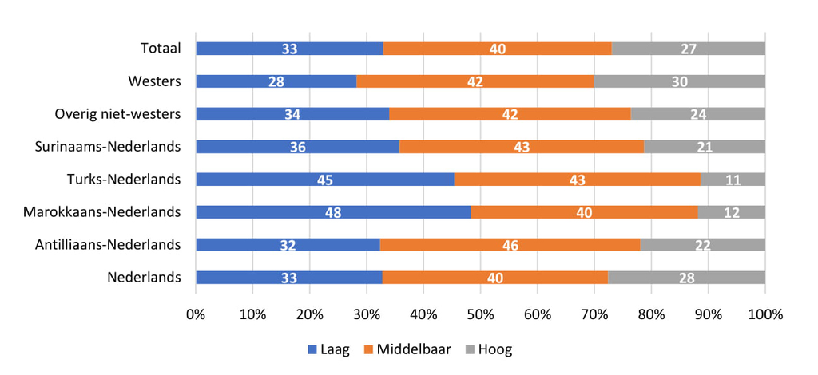

Bron: CBS 2018

## Opleidingsniveau Den Haag

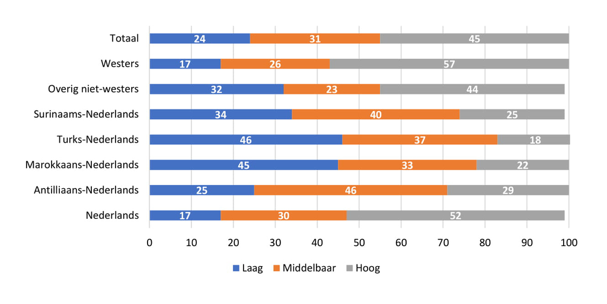

Bron: De Gruijter, Gilsing & Pels, 2014

## Voortijdigsschoolverlaten Den Haag(2011-2012) en Rotterdam (2014)

| Herkomst | n (DH) | % (DH) | n(R) | %(R) |
| --- | --- | --- | --- | --- |
| Nederlands | 545 | 4,0% | 1.657 | 5,1% |
| Antilliaans-Ned | 104 | 9,2% | 358 | 7,4% |
| Marokkaans-Ned | 187 | 5,7% | 517 | 6,1% |
| Turks-Ned | 228 | 5,4% | 645 | 6,9% |
| Surinaams-Ned | 203 | 4,8% | 375 | 6,3% |
| Niet-westers | 172 | 4,8% | 375 | 4,8% |
| Westers | 161 | 5,7 | 351 | 4,5% |

## Mogelijke verklaringen

> “Leerlingen met een migratieachtergrond verlaten school vaker vroegtijdig dan leerlingen met een Nederlandse achtergrond.Dit geldt met name voor jongeren met een Antilliaanse achtergrond.”

Samenstelling van gezin (eenoudergezin) vormt risicofactor (Traag & Van der Velden, 2008) - Minder sociale interactie - Minder gebruik maken van hulpbronnen

## De factsheet

De publicatie vind je hier:

https://www.verwey-jonker.nl/publicaties/2018/leefomstandigheden-inwoners-met-een-antilliaanse-achtergrond-in-den-haag.